# R Notebook

# Clustering

## Partitional clustering: KMeans

We will use an example with simulated data to demonstrate how the  
k -means algorithm works. Here we simulate some data from three clusters and plot the dataset below.

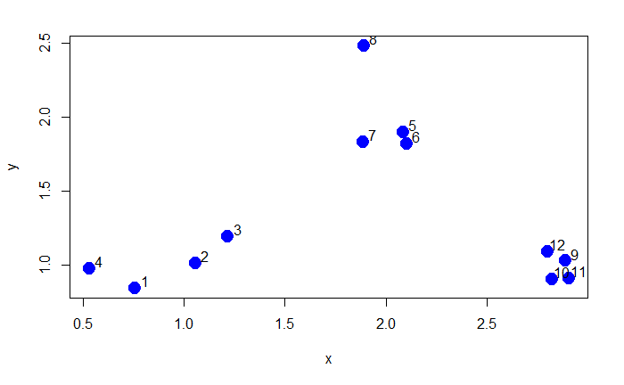

```r
set.seed(1234)
x <- rnorm(12,mean=rep(1:3,each=4),sd=0.2)
y <- rnorm(12,mean=rep(c(1,2,1),each=4),sd=0.2)
plot(x,y,col="blue",pch=19,cex=2)
text(x+0.05,y+0.05,labels=as.character(1:12))
```

The kmeans() function in R implements the k-means algorithm and can be found in the stats package, which comes with R and is usually already loaded when you start R. Two key parameters that you have to specify are x, which is a matrix or data frame of data, and centers which is either an integer indicating the number of clusters or a matrix indicating the locations of the initial cluster centroids. The data should be organized so that each row is an observation and each column is a variable or feature of that observation.

```r
dataFrame <- data.frame(x,y)
kmeansObj <- kmeans(dataFrame,centers=3)
names(kmeansObj)
```

```
[1] "cluster"      "centers"      "totss"        "withinss"     "tot.withinss" "betweenss"    "size"         "iter"         "ifault"
```

You can see which cluster each data point got assigned to by looking at the cluster element of the list returned by the kmeans() function.

```r
kmeansObj$cluster
```

```
 [1] 3 1 1 3 2 2 2 2 2 2 2 2
```

Here is a plot of the k-means clustering solution.

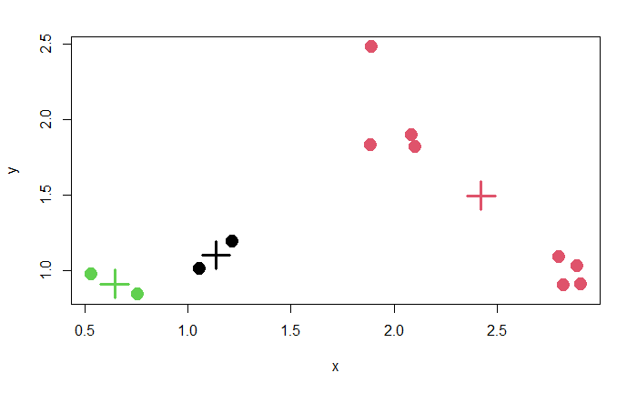

```r
plot(x,y,col=kmeansObj$cluster,pch=19,cex=2)
points(kmeansObj$centers,col=1:3,pch=3,cex=3,lwd=3)
```

### Determine the good number of clusters

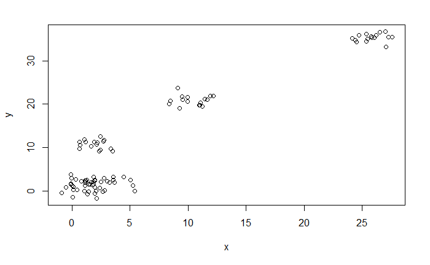

```r
n = 100
g = 6
set.seed(g)
d <- data.frame(x = unlist(lapply(1:g, function(i) rnorm(n/g, runif(1)*i^2))),
                y = unlist(lapply(1:g, function(i) rnorm(n/g, runif(1)*i^2))))
plot(d)
```

#### 1. Elbow method => SSE scree plot

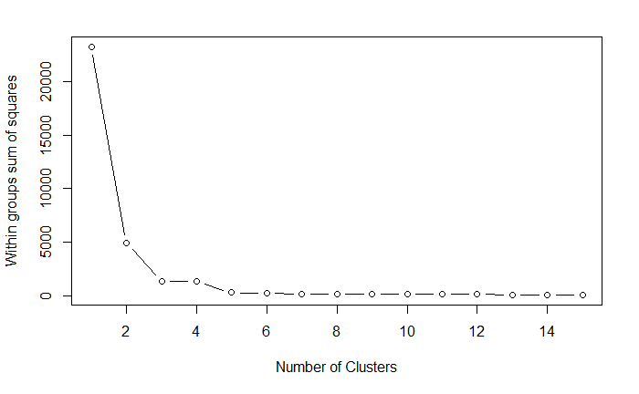

```r
mydata <- d
wss <- (nrow(mydata)-1)*sum(apply(mydata,2,var))
  for (i in 2:15) wss[i] <- sum(kmeans(mydata,
                                       centers=i)$withinss)
plot(1:15, wss, type="b", xlab="Number of Clusters",
     ylab="Within groups sum of squares")
```

#### 2. You can do partitioning around medoids to estimate the number of clusters using the pamk function in the fpc package.

```r
library(fpc)
pamk.best <- pamk(d)
cat("number of clusters estimated by optimum average silhouette width:", pamk.best$nc, "\n")
```

```
number of clusters estimated by optimum average silhouette width: 4
```

```r
plot(pam(d, pamk.best$nc))
```

[output not shown]

```r
# we could also do:
library(fpc)
asw <- numeric(20)
for (k in 2:20)
  asw[[k]] <- pamk(d, k) $ silinfo $ avg.width
```

[output not shown]

#### 3. Calinsky criterion: Another approach to diagnosing how many clusters suit the data. In this case we try 1 to 10 groups.

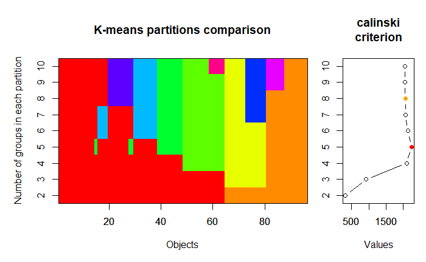

```r
require(vegan)
fit <- cascadeKM(scale(d, center = TRUE,  scale = TRUE), 1, 10, iter = 1000)
plot(fit, sortg = TRUE, grpmts.plot = TRUE)
```

```r
calinski.best <- as.numeric(which.max(fit$results[2,]))
cat("Calinski criterion optimal number of clusters:", calinski.best, "\n")
```

```
Calinski criterion optimal number of clusters: 5
```

```r
# 5 clusters!
```

#### 4. Determine the optimal model and number of clusters according to the Bayesian Information Criterion for expectation-maximization, initialized by hierarchical clustering for parameterized Gaussian mixture models

```r
# See http://www.jstatsoft.org/v18/i06/paper
# http://www.stat.washington.edu/research/reports/2006/tr504.pdf
#
library(mclust)
# Run the function to see how many clusters
# it finds to be optimal, set it to search for
# at least 1 model and up 20.
d_clust <- Mclust(as.matrix(d), G=1:20)
```

```
fitting ...
```

```r
m.best <- dim(d_clust$z)[2]
cat("model-based optimal number of clusters:", m.best, "\n")
```

```
model-based optimal number of clusters: 4
```

```r
# 4 clusters
plot(d_clust)
```

```
Model-based clustering plots:

1: BIC
2: classification
3: uncertainty
4: density
```

```r
1
```

```
Model-based clustering plots:

1: BIC
2: classification
3: uncertainty
4: density
```

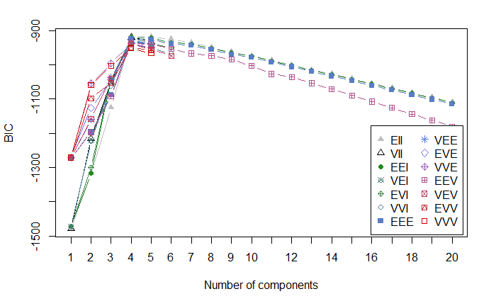

```
Model-based clustering plots:

1: BIC
2: classification
3: uncertainty
4: density
```

```r
BIC
```

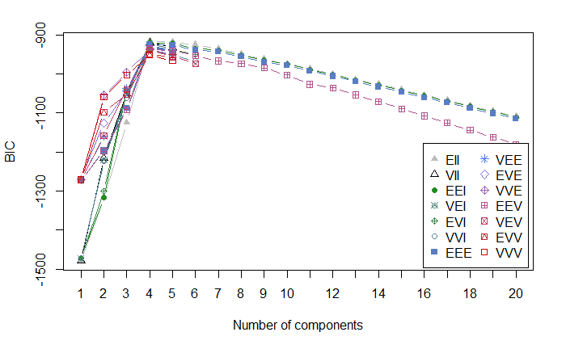

```
Model-based clustering plots:

1: BIC
2: classification
3: uncertainty
4: density
```

```r
classification
```

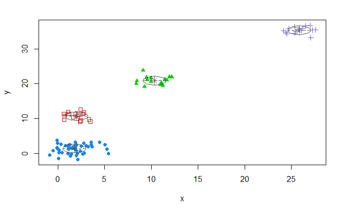

```
Model-based clustering plots:

1: BIC
2: classification
3: uncertainty
4: density
```

```r
uncertainty
```

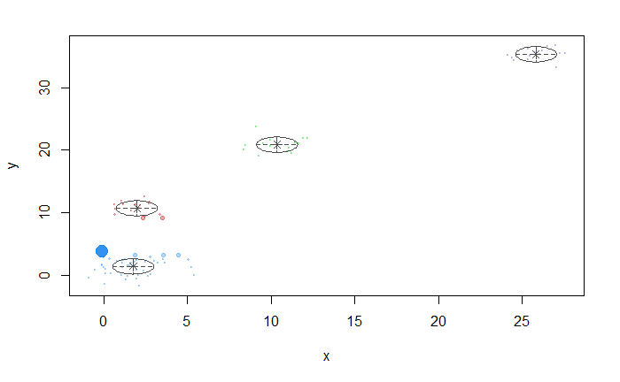

```
Model-based clustering plots:

1: BIC
2: classification
3: uncertainty
4: density
```

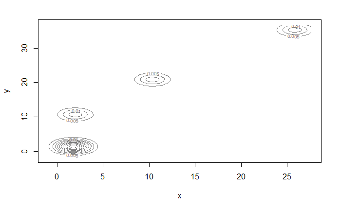

```r
density
```

#### 5. Affinity propagation (AP) clustering, see http://dx.doi.org/10.1126/science.1136800

```r
library(apcluster)
d.apclus <- apcluster(negDistMat(r=2), d)
cat("affinity propogation optimal number of clusters:", length(d.apclus@clusters), "\n")
```

```
affinity propogation optimal number of clusters: 4
```

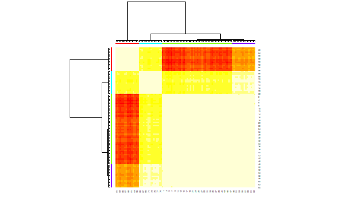

```r
# 4
heatmap(d.apclus)
```

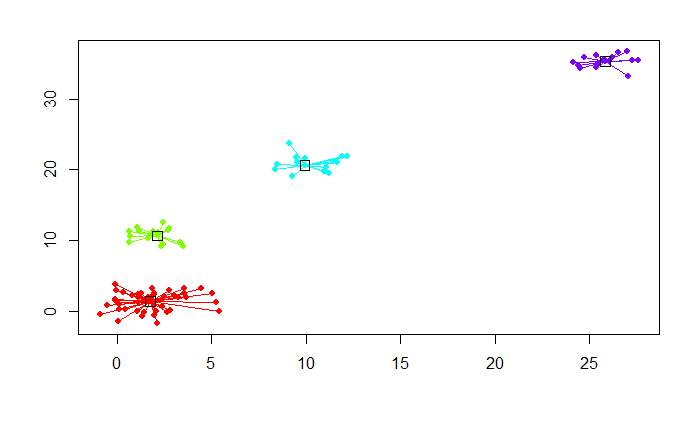

```r
plot(d.apclus, d)
```

```r
library(cluster)
clusGap(d, kmeans, 10, B = 100, verbose = interactive())
```

```
Clustering k = 1,2,..., K.max (= 10): .. done
Bootstrapping, b = 1,2,..., B (= 100)  [one "." per sample]:
.................................................. 50
.................................................. 100
Clustering Gap statistic ["clusGap"] from call:
clusGap(x = d, FUNcluster = kmeans, K.max = 10, B = 100, verbose = interactive())
B=100 simulated reference sets, k = 1..10; spaceH0="scaledPCA"
 --> Number of clusters (method 'firstSEmax', SE.factor=1): 4
          logW   E.logW         gap     SE.sim
 [1,] 5.991701 5.966577 -0.02512452 0.03864501
 [2,] 5.281368 5.363617  0.08224842 0.04019969
 [3,] 4.557779 5.065608  0.50782936 0.03534141
 [4,] 3.928959 4.883942  0.95498344 0.03759982
 [5,] 3.789319 4.773885  0.98456606 0.04700319
 [6,] 3.730007 4.679183  0.94917629 0.04527097
 [7,] 3.600933 4.589424  0.98849040 0.04396380
 [8,] 3.553329 4.510908  0.95757916 0.05396233
 [9,] 3.493739 4.432806  0.93906715 0.05261964
[10,] 3.434284 4.361310  0.92702526 0.05749033
```

#### 7. Clustergram

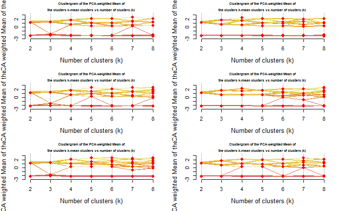

```r
library(devtools)
source("https://raw.github.com/talgalili/R-code-snippets/master/clustergram.r")
set.seed(500)
Data <- scale(iris[,-5]) # notice I am scaling the vectors)
par(cex.lab = 1.2, cex.main = .7)
par(mfrow = c(3,2))
for(i in 1:6) clustergram(Data, k.range = 2:8 , line.width = .004, add.center.points = T)
```

```r
library(NbClust)
nb <- NbClust(d, diss=NULL, distance = "euclidean",
        method = "kmeans", min.nc=2, max.nc=15,
        index = "alllong", alphaBeale = 0.1)
hist(nb$Best.nc[1,], breaks = max(na.omit(nb$Best.nc[1,])))
```

[output not shown]

## Hierarchical clustering

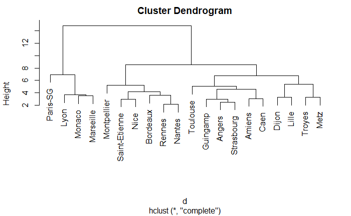

```r
# Load the dataset
ligue1 <- read.csv("datasets/ligue1_17_18.csv", row.names=1,sep=";")

# Work with standardized data
ligue1_scaled <- data.frame(scale(ligue1))

# Compute dissimilary matrix - in this case Euclidean distance
d <- dist(ligue1_scaled)

# Hierarchical clustering with complete linkage
treeComp <- hclust(d, method = "complete")
plot(treeComp)
```

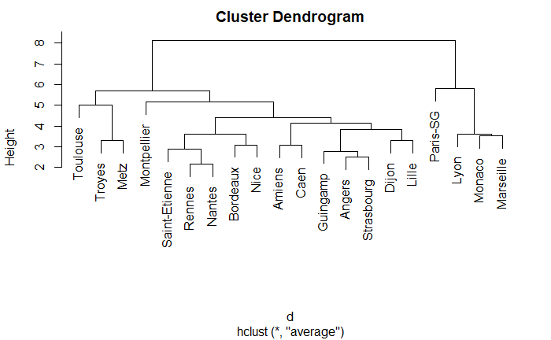

```r
# With average linkage
treeAve <- hclust(d, method = "average")
plot(treeAve)
```

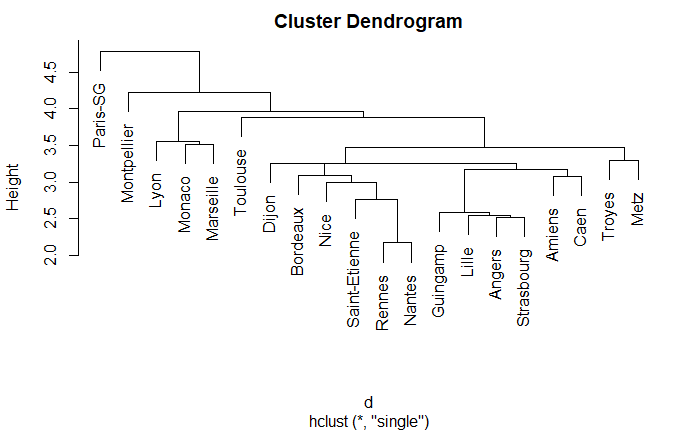

```r
# With single linkage
treeSingle <- hclust(d, method = "single")
plot(treeSingle) # Chaining
```

```r
# Set the number of clusters after inspecting visually
# the dendrogram for "long" groups of hanging leaves
# These are the cluster assignments
cutree(treeComp, k = 2)
```

```
     Paris-SG        Monaco          Lyon     Marseille        Rennes      Bordeaux Saint-Etienne          Nice        Nantes   Montpellier         Dijon      Guingamp        Amiens
            1             1             1             1             2             2             2             2             2             2             2             2             2
       Angers    Strasbourg          Caen         Lille      Toulouse        Troyes          Metz
            2             2             2             2             2             2             2
```

```r
 cutree(treeComp, k = 3)
```

```
     Paris-SG        Monaco          Lyon     Marseille        Rennes      Bordeaux Saint-Etienne          Nice        Nantes   Montpellier         Dijon      Guingamp        Amiens
            1             1             1             1             2             2             2             2             2             2             3             3             3
       Angers    Strasbourg          Caen         Lille      Toulouse        Troyes          Metz
            3             3             3             3             3             3             3
```

```r
cutree(treeComp, k = 4)
```

```
     Paris-SG        Monaco          Lyon     Marseille        Rennes      Bordeaux Saint-Etienne          Nice        Nantes   Montpellier         Dijon      Guingamp        Amiens
            1             2             2             2             3             3             3             3             3             3             4             4             4
       Angers    Strasbourg          Caen         Lille      Toulouse        Troyes          Metz
            4             4             4             4             4             4             4
```